# WeRateDogs Twitter Archive - act Report

## Introduction

> WeRateDogs is a Twitter account that rates people's dogs with a humorous comment about the dog. These ratings almost always have a denominator of 10. The numerators however are almost always greater than 10 (11/10, 12/10, 13/10, etc.). In theory the rates should be 1 to 10. However, WeRateDogs disagree, they admit almost all dogs deserve a 10 and sometimes more than that. WeRateDogs has over 4 million followers and has received international media coverage.

> In this report I communicate the insights and display the visualizations produced from my wrangled data.

## Insights and visualizations

### Most common dog type

> WeRateDogs has over 6000+ tweets. I was able to analyzed around 1500+ tweets. The most rated dog was golden retriever with more than 139 ratings.

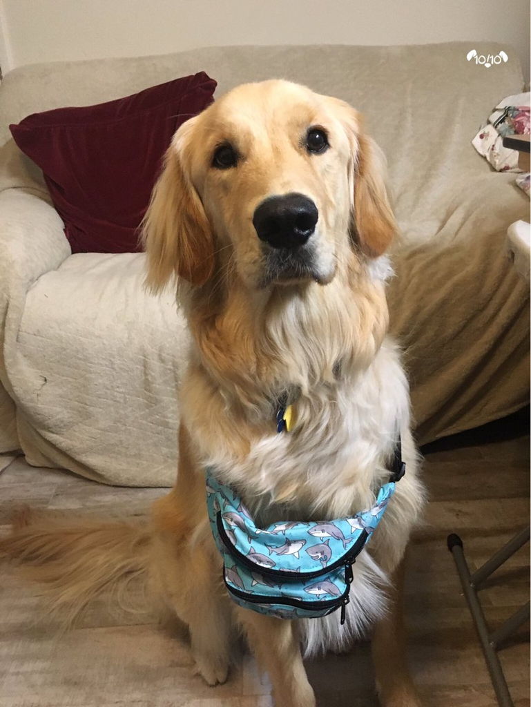

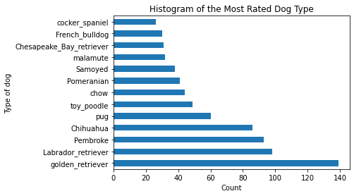

### The highest and lowest dog stage

- **pupper** is the highest dog stage
- **floofer** is the lowest dog stage

### Lowest average rating among dog types

> Almost all dogs deserve ratings above 10. This is a notable exception, This Japanese spaniel has the lowest average rating.

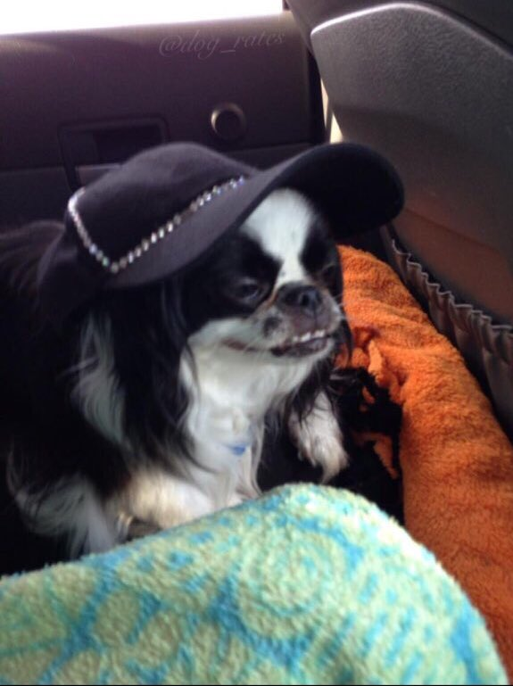

### Relationship between retweet_count and favorite_count

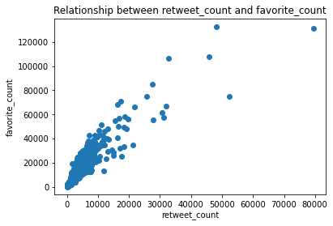

> - there is linear relationship between **retweet_count** and **favorite_count**.

### Relationship between rating and favorite_count

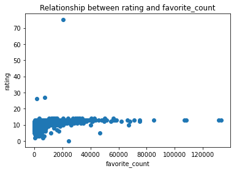

> Amazingly many tweets have been liked more than 10000 times some more than even 120000 times. There is not a clear relationship between the ratings and favorite_count.

### Relationship between rating and retweet_count

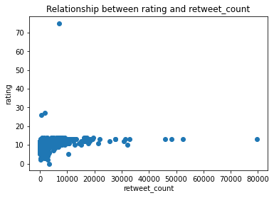